#**Chapter 2: Simple Linear Regression**

##*Author: J Wooldridge*

###**Regression Practice**

#**Exapmple 2.3 CEO Salary and Return on Equity**

```
##    Min. 1st Qu.  Median    Mean 3rd Qu.    Max.
##     223     736    1039    1281    1407   14822
```

```
##    Min. 1st Qu.  Median    Mean 3rd Qu.    Max.
##    0.50   12.40   15.50   17.18   20.00   56.30
```

```
##
## Call:
## lm(formula = salary ~ roe, data = ceosal1)
##
## Residuals:
##     Min      1Q  Median      3Q     Max
## -1160.2  -526.0  -254.0   138.8 13499.9
##
## Coefficients:
##             Estimate Std. Error t value Pr(>|t|)
## (Intercept)   963.19     213.24   4.517 1.05e-05 ***
## roe            18.50      11.12   1.663   0.0978 .
## ---
## Signif. codes:  0 '***' 0.001 '**' 0.01 '*' 0.05 '.' 0.1 ' ' 1
##
## Residual standard error: 1367 on 207 degrees of freedom
## Multiple R-squared:  0.01319,    Adjusted R-squared:  0.008421
## F-statistic: 2.767 on 1 and 207 DF,  p-value: 0.09777
```

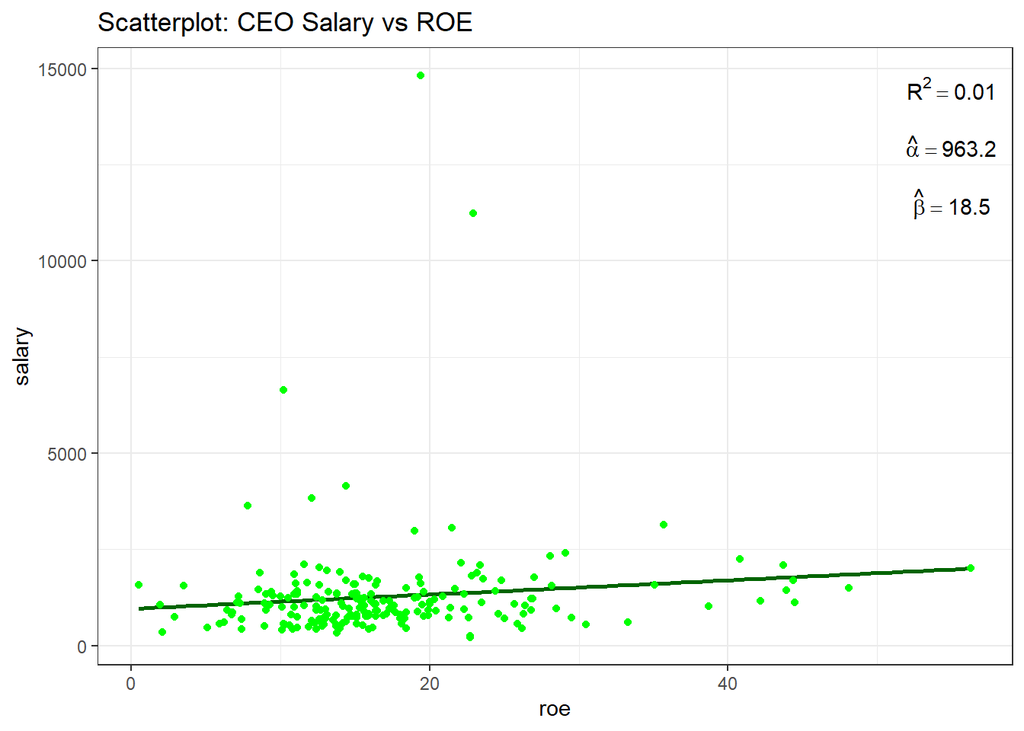

**Interpretation:**  
If the ROE of the the firm increases by 1 percentage point than the CEO’s salary increasese by **18.5** thousand dollars.

#**Exapmple 2.4 Wage and Education**

Consider the scatterplot of wage vs education from the wage dataset and the OLS model estimates

```
##
## Call:
## lm(formula = wage ~ educ, data = wage1)
##
## Residuals:
##     Min      1Q  Median      3Q     Max
## -5.3396 -2.1501 -0.9674  1.1921 16.6085
##
## Coefficients:
##             Estimate Std. Error t value Pr(>|t|)
## (Intercept) -0.90485    0.68497  -1.321    0.187
## educ         0.54136    0.05325  10.167   <2e-16 ***
## ---
## Signif. codes:  0 '***' 0.001 '**' 0.01 '*' 0.05 '.' 0.1 ' ' 1
##
## Residual standard error: 3.378 on 524 degrees of freedom
## Multiple R-squared:  0.1648, Adjusted R-squared:  0.1632
## F-statistic: 103.4 on 1 and 524 DF,  p-value: < 2.2e-16
```

```
##
## Call:
## lm(formula = wage ~ educ, data = wage1)
##
## Coefficients:
## (Intercept)         educ
##     -0.9049       0.5414
```

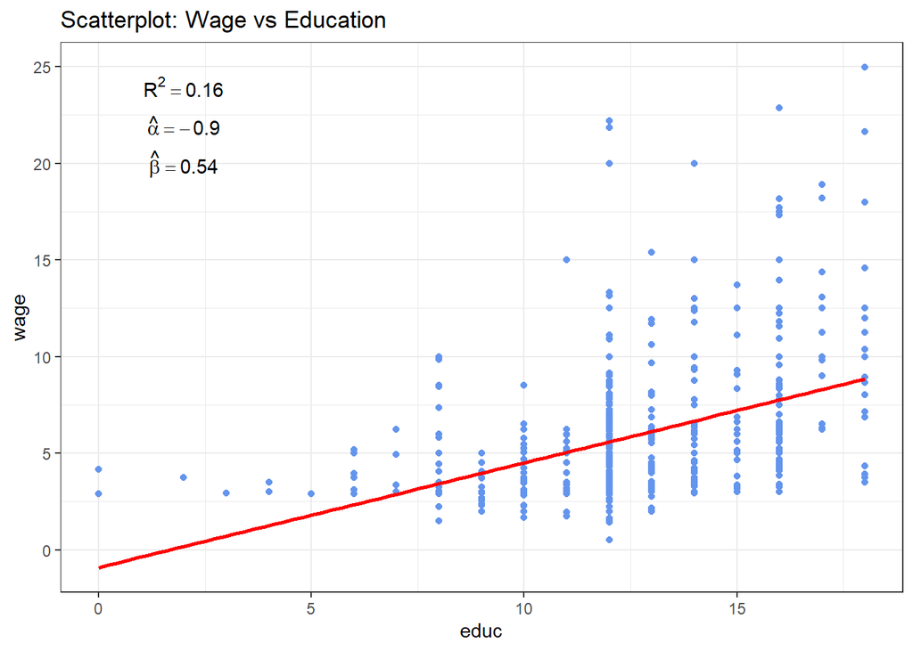

#**Exapmple 2.5 Voting Outcomes and Campaign Expenditures**

```
##   state district democA voteA expendA expendB prtystrA lexpendA lexpendB
## 1    AL        7      1    68 328.296   8.737       41 5.793916 2.167567
## 2    AK        1      0    62 626.377 402.477       60 6.439952 5.997638
## 3    AZ        2      1    73  99.607   3.065       55 4.601233 1.120048
## 4    AZ        3      0    69 319.690  26.281       64 5.767352 3.268846
## 5    AR        3      0    75 159.221  60.054       66 5.070293 4.095244
## 6    AR        4      1    69 570.155  21.393       46 6.345908 3.063064
##     shareA
## 1 97.40767
## 2 60.88104
## 3 97.01476
## 4 92.40370
## 5 72.61247
## 6 96.38355
```

```
##
## Call:
## lm(formula = voteA ~ shareA, data = vote1)
##
## Residuals:
##      Min       1Q   Median       3Q      Max
## -16.8919  -4.0660  -0.1682   3.4965  29.9772
##
## Coefficients:
##             Estimate Std. Error t value Pr(>|t|)
## (Intercept) 26.81221    0.88721   30.22   <2e-16 ***
## shareA       0.46383    0.01454   31.90   <2e-16 ***
## ---
## Signif. codes:  0 '***' 0.001 '**' 0.01 '*' 0.05 '.' 0.1 ' ' 1
##
## Residual standard error: 6.385 on 171 degrees of freedom
## Multiple R-squared:  0.8561, Adjusted R-squared:  0.8553
## F-statistic:  1018 on 1 and 171 DF,  p-value: < 2.2e-16
```

```
##
## Call:
## lm(formula = voteA ~ shareA, data = vote1)
##
## Coefficients:
## (Intercept)       shareA
##     26.8122       0.4638
```

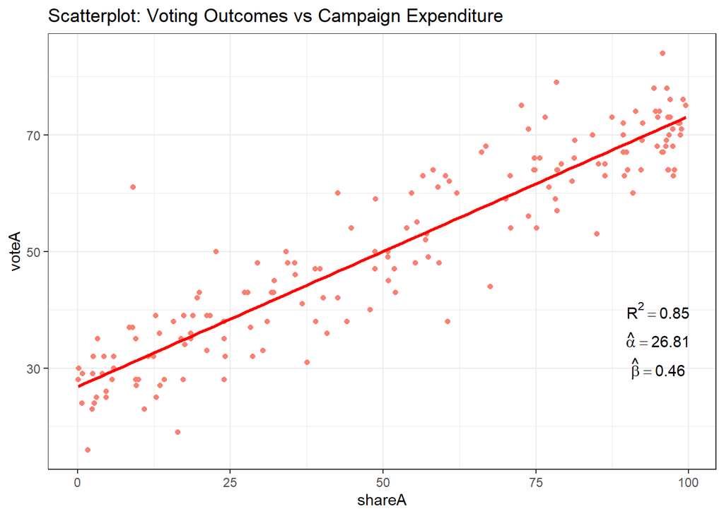

**Interpretation:** Vote share increases by almost half a percent if Cadidate A increases his campaign spending by 1 percent in the total campaign spending among both.

#**Example 2.6 CEO Salary and ROE**

```
## [1] 1281.119
```

```
## [1] 1281.12
```

```
##
## Call:
## lm(formula = salary ~ roe, data = ceosal1)
##
## Residuals:
##     Min      1Q  Median      3Q     Max
## -1160.2  -526.0  -254.0   138.8 13499.9
##
## Coefficients:
##             Estimate Std. Error t value Pr(>|t|)
## (Intercept)   963.19     213.24   4.517 1.05e-05 ***
## roe            18.50      11.12   1.663   0.0978 .
## ---
## Signif. codes:  0 '***' 0.001 '**' 0.01 '*' 0.05 '.' 0.1 ' ' 1
##
## Residual standard error: 1367 on 207 degrees of freedom
## Multiple R-squared:  0.01319,    Adjusted R-squared:  0.008421
## F-statistic: 2.767 on 1 and 207 DF,  p-value: 0.09777
```

```
## [1] 0.0121
```

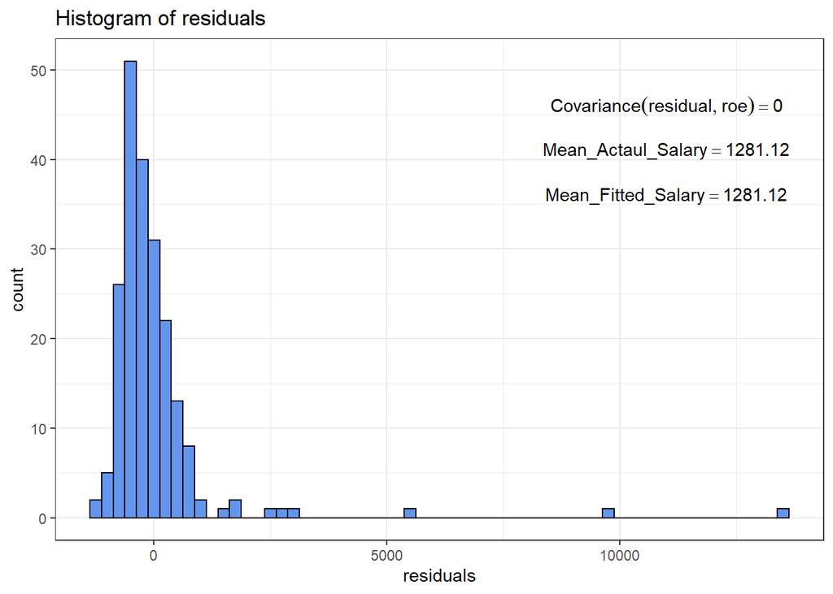

#**Example 2.7 Wage and Education**  
No Analysis required

#**Example 2.8 CEO Salary and ROE**  
The correlation between predicted salary and observed salary is **0.11**. This when squared yields **0.01**.

The results of regression of salary on roe are:

```
##
## Call:
## lm(formula = salary ~ roe, data = ceosal1)
##
## Residuals:
##     Min      1Q  Median      3Q     Max
## -1160.2  -526.0  -254.0   138.8 13499.9
##
## Coefficients:
##             Estimate Std. Error t value Pr(>|t|)
## (Intercept)   963.19     213.24   4.517 1.05e-05 ***
## roe            18.50      11.12   1.663   0.0978 .
## ---
## Signif. codes:  0 '***' 0.001 '**' 0.01 '*' 0.05 '.' 0.1 ' ' 1
##
## Residual standard error: 1367 on 207 degrees of freedom
## Multiple R-squared:  0.01319,    Adjusted R-squared:  0.008421
## F-statistic: 2.767 on 1 and 207 DF,  p-value: 0.09777
```

#**Example 2.9 Voting Outcomes and Campaign Expenditures**  
The regresssion outcome as indicated by the plot, cleary, seems to be a better fit for the model. But, How much better?

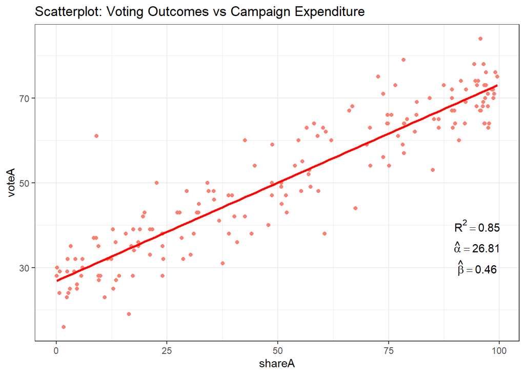

We check the R-Square also called the, Coefficient of Determination. In this case the R square value is **0.8561409**.

#**2-4 Units of Measurement and Functional Form (Page 36)**  
(1)Change in DEPENDENT VARIABLE UNIT  
Consider the case of CEO_Sal regressed on ROE. Here, CEO_Sal is interms of thousands of $ and ROE is measured as percentage. If CEO_Sal is instead changed to 100s, what would the impact on beta and alpha?

The new regression result is as follows:

```
##   salary pcsalary   sales  roe pcroe ros indus finance consprod utility
## 1   1095       20 27595.0 14.1 106.4 191     1       0        0       0
## 2   1001       32  9958.0 10.9 -30.6  13     1       0        0       0
## 3   1122        9  6125.9 23.5 -16.3  14     1       0        0       0
## 4    578       -9 16246.0  5.9 -25.7 -21     1       0        0       0
## 5   1368        7 21783.2 13.8  -3.0  56     1       0        0       0
## 6   1145        5  6021.4 20.0   1.0  55     1       0        0       0
##    lsalary    lsales
## 1 6.998509 10.225389
## 2 6.908755  9.206132
## 3 7.022868  8.720281
## 4 6.359574  9.695602
## 5 7.221105  9.988894
## 6 7.043160  8.703075
```

```
##   salary  roe sal_100
## 1   1095 14.1   10950
## 2   1001 10.9   10010
## 3   1122 23.5   11220
## 4    578  5.9    5780
## 5   1368 13.8   13680
## 6   1145 20.0   11450
```

```
## (Intercept)         roe
##   9631.9134    185.0119
```

The old regression (CEO_sal on ROE) result was

```
## (Intercept)         roe
##   963.19134    18.50119
```

Notice, both intercept and slope get multiplied by **10**.  
**In General, for every multiplication or division by any constant ‘c’ to the DEPENDENT variable must be repeated across all intercept and independent variable.**

(2)Change in INDEPENDENT VARIABLE UNIT  
Consider the case of CEO_Sal regressed on ROE. Here, CEO_Sal is interms of thousands of $ and ROE is measured as percentage. If ROE is instead changed to its decimal form, what would the impact on beta and alpha?

The new regression result is as follows:

```
##   salary pcsalary   sales  roe pcroe ros indus finance consprod utility
## 1   1095       20 27595.0 14.1 106.4 191     1       0        0       0
## 2   1001       32  9958.0 10.9 -30.6  13     1       0        0       0
## 3   1122        9  6125.9 23.5 -16.3  14     1       0        0       0
## 4    578       -9 16246.0  5.9 -25.7 -21     1       0        0       0
## 5   1368        7 21783.2 13.8  -3.0  56     1       0        0       0
## 6   1145        5  6021.4 20.0   1.0  55     1       0        0       0
##    lsalary    lsales
## 1 6.998509 10.225389
## 2 6.908755  9.206132
## 3 7.022868  8.720281
## 4 6.359574  9.695602
## 5 7.221105  9.988894
## 6 7.043160  8.703075
```

```
##   salary  roe roe_dec
## 1   1095 14.1   0.141
## 2   1001 10.9   0.109
## 3   1122 23.5   0.235
## 4    578  5.9   0.059
## 5   1368 13.8   0.138
## 6   1145 20.0   0.200
```

```
## (Intercept)     roe_dec
##    963.1913   1850.1186
```

The old regression (CEO_sal on ROE) result was

```
## (Intercept)         roe
##   963.19134    18.50119
```

Notice, only beta changes and alpha remains unchanged. ROE is multiplied by 100 for a division of 100 of the independent’s units.

**In General, every multiplication or division by any constant ‘c’ to the INDEPENDENT variable must be repeated with division or multiplication resp of across DEPENDENT ONLY.**